# Graphics in R

## Box plots & others

A Boxplot needs all the data to be able to display the distribution of values, so we’ll be using the whole data frame again.

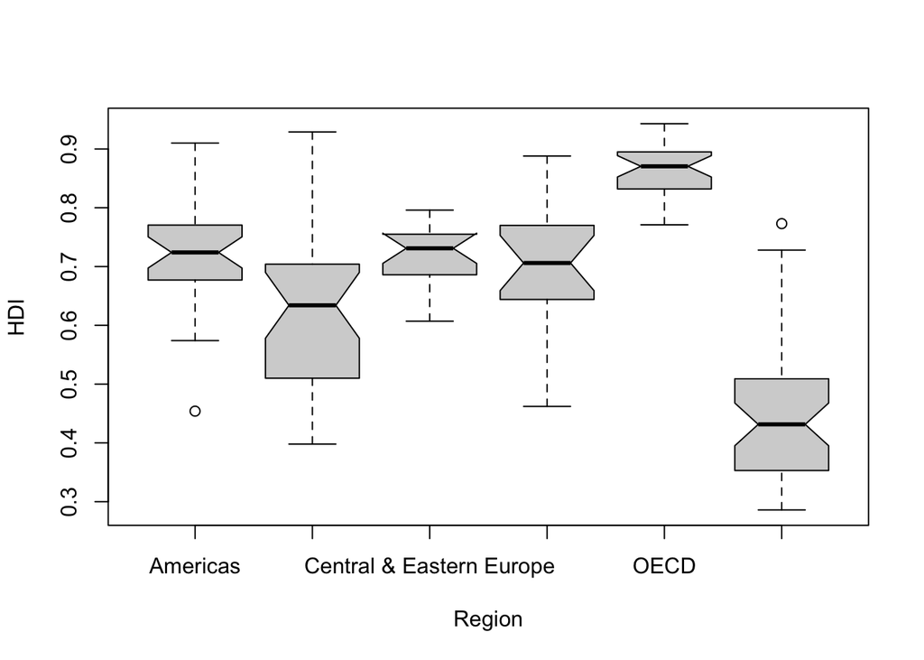

```r
# boxplot of HDI by Region using built-in graphics.
boxplot( HDI ~ Region, data=df, notch=TRUE)
```

Now the same using `ggplot`.

```
notch went outside hinges. Try setting notch=FALSE.
```

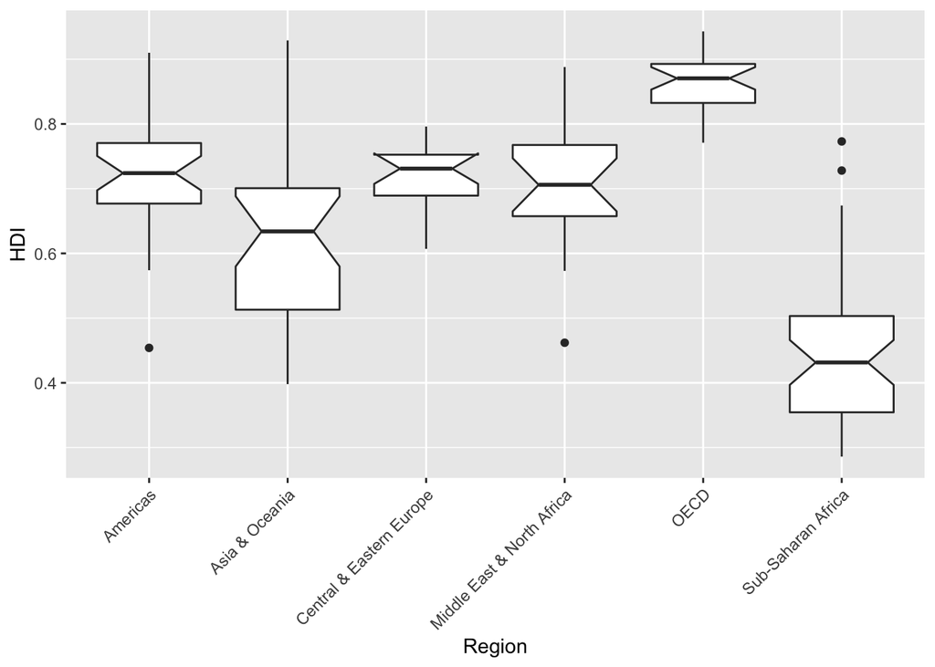

```r
# GGPlot geom_boxplot
ggplot( df, aes(Region,HDI) ) +
  geom_boxplot( notch=TRUE ) +
  theme(axis.text.x = element_text(angle = 45, hjust=1))
```

The `ggplot` library has additional ways to visualize these kinds of data. Look at the CheatSheet if you need assistance or the built-in help file for `geom_violin` to make this plot.

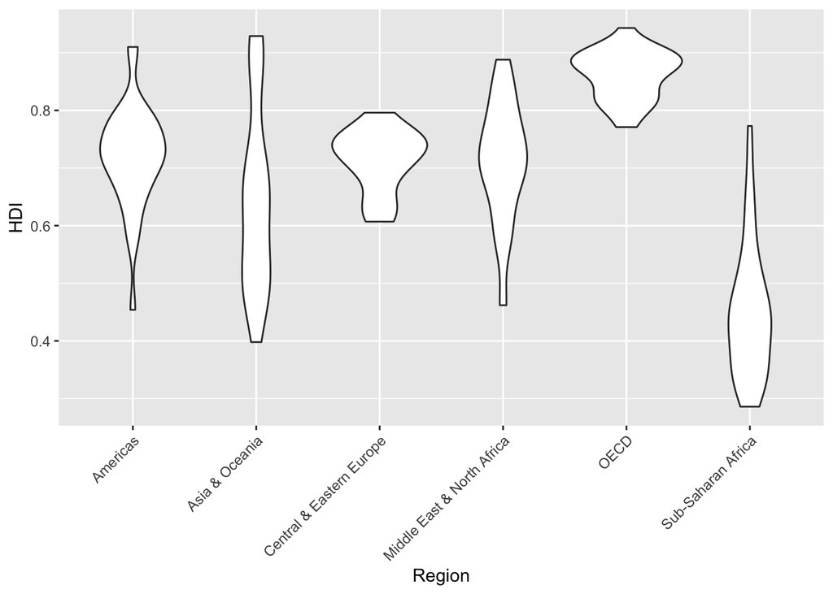

```r
# Look up geom_violin and use that for plotting
ggplot( df, aes(Region,HDI) ) +
  geom_violin() +
  theme(axis.text.x = element_text(angle = 45, hjust=1))
```

### Adding Colors

Take the violin plot above and color each region in a different color.

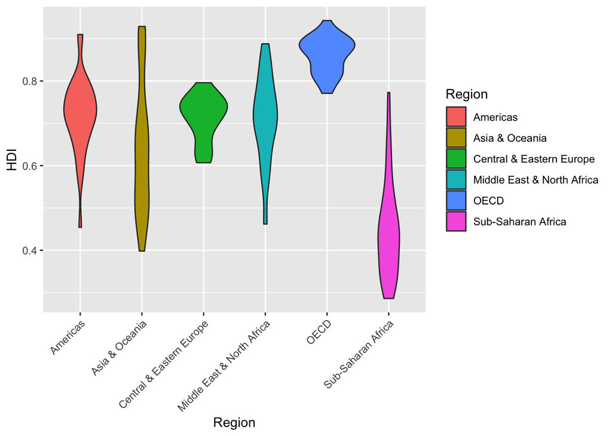

```r
ggplot( df, aes(Region,HDI, fill=Region) ) +
  geom_violin() +
  theme(axis.text.x = element_text(angle = 45, hjust=1))
```

# Continuous Bivariate Data

Using the built-in `plot()` function create the following scatter plots. *Make sure to include a legend.*

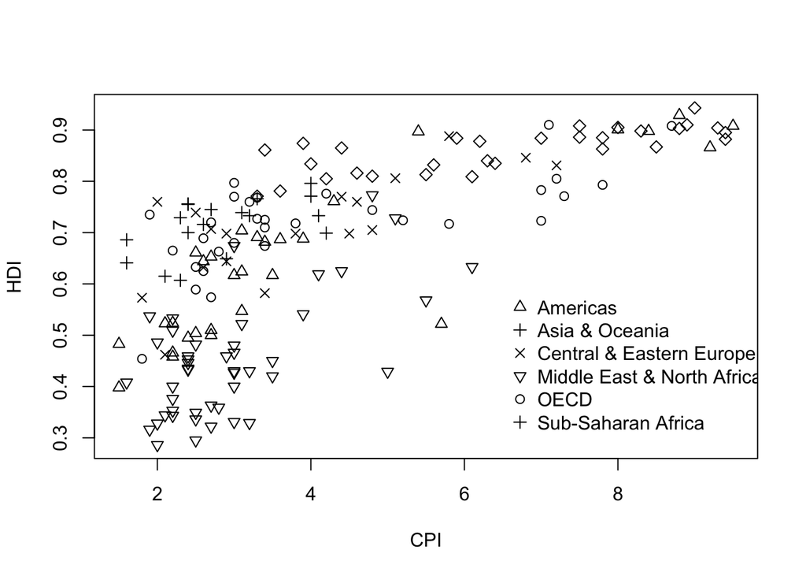

```r
# HDI as a function of CPI with Regions defined by plot character
plot( HDI ~ CPI, data=df, pch=as.numeric(Region))
legend( 6.5,0.6, legend=levels(df$Region), pch=as.numeric( df$Region) , bty="n")
```

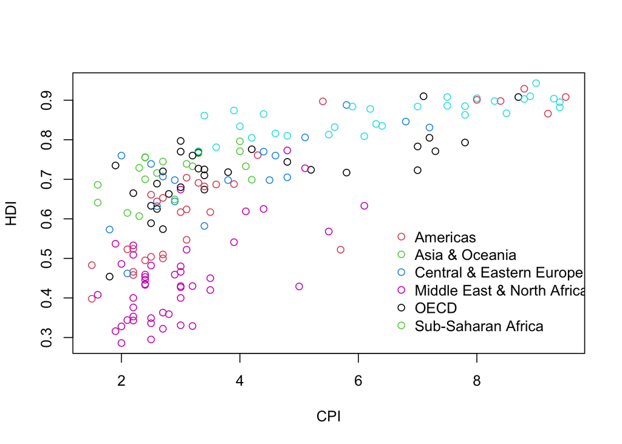

```r
# HDI as a function of CPI with Regions defined by color
plot( HDI ~ CPI, data=df, col=as.numeric(Region))
legend( 6.5,0.6, legend=levels(df$Region), col=as.numeric( df$Region), pch=1, bty="n")
```

Now do the same with `ggplot` using regions as either plot character or color.

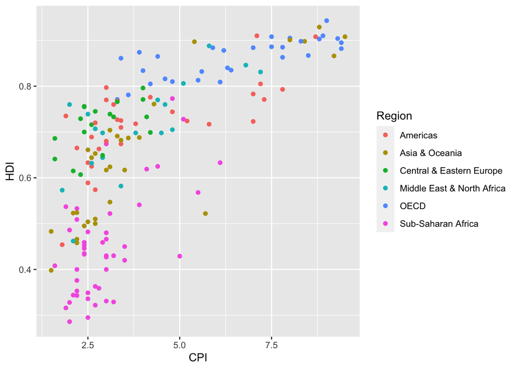

```r
# HDI as function of CPI with Region differences.
ggplot( df, aes(CPI,HDI, color=Region) ) + geom_point()
```

# Labels

OK, so the last thing we are going to do is define a separate `data.frame` that has just the labels so we can make it look a bit like the original plot. To do this, I define a new data.frame with just the countries that I’m interested in plotting.

```r
df.labels <- data.frame( Country = c("Russia", "Venezuela", "Iraq", "Myanmar", "Sudan",
                                     "Afghanistan", "Congo", "Greece", "Argentina", "Brazil",
                                     "India", "Italy", "China", "South Africa", "Spane",
                                     "Botswana", "Cape Verde", "Bhutan", "Rwanda", "France",
                                     "United States", "Germany", "Britain", "Barbados", "Norway",
                                     "Japan","New Zealand", "Singapore")
)
```

Next, I take this new data.frame and the original one and use the `merge()` function.

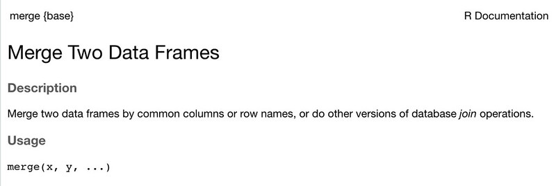

*Figure 2:* Help file for `merge()`.

What this function *requires* is that the two data.frames **must** have a colum with the same name. In this case, both the original data.frame had one named `Country` as did the new one. I’m assuming that the original data was loaded in as the variable `df` as requested above—if you named it something else, then replace your variable name with the `df` in the first line of the code below.

```r
df.labels <- merge( df.labels, df)
df.labels
```

| Country | HDI | CPI | Region |
| --- | --- | --- | --- |
| Afghanistan | 0.398 | 1.5 | Asia & Oceania |
| Argentina | 0.797 | 3.0 | Americas |
| Barbados | 0.793 | 7.8 | Americas |
| Bhutan | 0.522 | 5.7 | Asia & Oceania |
| Botswana | 0.633 | 6.1 | Sub-Saharan Africa |
| Brazil | 0.718 | 3.8 | Americas |
| Britain | 0.863 | 7.8 | OECD |
| Cape Verde | 0.568 | 5.5 | Sub-Saharan Africa |
| China | 0.687 | 3.6 | Asia & Oceania |
| Congo | 0.286 | 2.0 | Sub-Saharan Africa |

[output cut: 17 more lines]

Now, let’s load in the `ggrepel` library[^1] and use both of these data.frames to add labels to a scatter plot. To do this, you’ll have to use the full data frame to lay down a `geom_point()` layer and then add the `geom_text_repel()` layer using the other `df.labels` data.frame. To make it look right, you may need to futz around with the various data mappings in the `aes` functions.

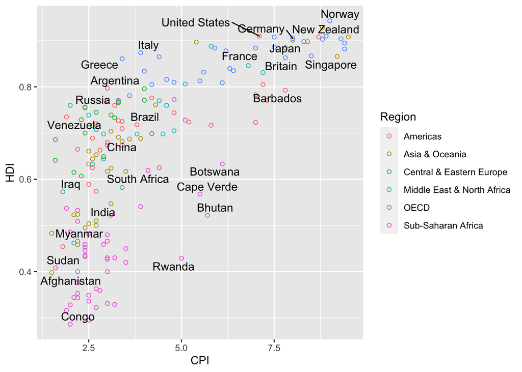

```r
library( ggrepel )
ggplot(df, aes(CPI, HDI) ) +
  geom_point( pch=1, aes(color=Region) ) +
  geom_text_repel( aes(label=Country), data=df.labels)
```

[^1]: If you get an error when trying to load in the ggrepel library saying it could not find the library, then install it using `install.packages("ggrepel")`.